# Case 2.1 - Cleaning up a messy dataset

In this case study, we will calculate each individual’s BMI from their weight and height measurements at three timepoints, at birth and at two exam days where the children are about 2 and 9 years of age. We will deal with a dataset that is more problematic than the previous, as it is less straight forward to load and contains missing data. We are going to clean the data up before computing BMI, by removing outliers and imputing missing data.

We need to install a package for the specific imputation method we will be using.

```r
install.packages("missForest")
```

```r
library(readr)  # For reading the data.
library(tibble)  # The "tibble" datastructure.
library(dplyr)  # Working with the tibble datastructure.
library(ggplot2)  # Plotting.
library(lubridate)  # Working with datetime objects.
library(missForest)  # For imputing missing values.
library(magrittr)  # Need this for the %>% operator.
library(devtools)  # For printing the session info at the end of the notebook.
```

We will also need the following script to make some of the plots in this notebook.

> Multiplot:

> http://www.cookbook-r.com/Graphs/Multiple_graphs_on_one_page_(ggplot2)/

We have saved this script somewhere on the computer, and run the script to load the functions in it. After running the script, we have the `multiplot()` function available.

```r
source("../multiplot.R")
```

# Reading and cleaning data

The data we want to load is CSV. However, it doesn’t use the standard comma delimitation as CSV files do; if we open the file in a text editor, we find that it uses semicolon. So we use `read_delim()` and specify `delim=';'`. Second, the first line in the file is not a proper entry in the CSV format, it is just a line of free text; we ignore this line using the `skip=1` argument. Finally, the file contains some whitespace, which will give our columns messy names with a bunch of spaces in them; we fix this using `trim_ws=TRUE`.

```r
data <- read_delim('weight_height_data.csv', delim=';', skip=1, trim_ws=TRUE)
```

You can download the data we use in this case here:

> https://olavurmortensen.github.io/r-for-statistics/notebooks/case_studies/children_biometric_studies/weight_height_data.csv

As in previous examples, we will give the variables convenient names, remove unnecessary variables, and convert character variables to factors.

```r
data = data %>% rename("ID" = "Identification number", "birth" = "Date of birth", "gender" = "Gender",
              "w0" = "Weight_birth", "h0" = "Height_birth", "exam1" = "Exam_day1", "h1" = "Height_1",
              "w1" = "Weight_1", "exam2" = "Exam_day2", "h2" = "Height_2", "w2" = "Weight_2")
data <- data %>% select(-'ID')
data <- data %>% mutate(gender=as.factor(gender))
```

```r
head(data)
```

| gender | birth | w0 | h0 | exam1 | h1 | w1 | exam2 | h2 | w2 |
| --- | --- | --- | --- | --- | --- | --- | --- | --- | --- |
| Female | 30-Dec-06 | 3700 | 55 | 14.08.08 | 86 | 15.2 | 16.01.2015 | 142.2 | 46.1 |
| Male | 28-Dec-06 | 3300 | 57 | 13.08.08 | 84 | 12.6 | NA | NA | NA |
| Female | 27-Dec-06 | 4210 | 56 | 15.08.08 | 82 | 11.7 | 13.11.2015 | 135.7 | 35.8 |
| Male | 26-Dec-06 | 3900 | 61 | 16.08.08 | 83 | 11.1 | 22.01.2015 | 132.5 | 27.8 |
| Male | 23-Dec-06 | 3050 | 51 | 08.08.08 | 79 | 10.0 | 23.01.2015 | 135.0 | 32.7 |
| Female | 22-Dec-06 | 3460 | 54 | 19.08.08 | 82 | 11.4 | 11.11.2015 | 144.1 | 34.4 |

Note that the birth weight is in grams, while the other weight measurements are in kilograms, so we will convert the birth weight. We do this using the `mutate()` function, calculating the new vaue `w0 / 1000` and storing it in the `w0` variable, thereby replacing the original values in the `w0` variable.

We also convert the height measures to meters, because we want to compute BMI which unit is $kg/m^2$.

```r
# Convert birth weight from grams to kilograms, to match the other weight units.
data = data %>% mutate(w0=w0/1000)
# Convert height measures to meters.
data = data %>% mutate(h0=h0/100)
data = data %>% mutate(h1=h1/100)
data = data %>% mutate(h2=h2/100)
```

We want to know the ages of the children at exam day 1 and 2. Unfortunately, working with dates can be a hassle, because of irregular formatted dates, and not completely straight-forward math in computing the time differences. Luckily, the `lubridate` package makes things (relatively) easy for us.

All the dates are are formatted as days, months and years, but examples include “30-Dec-06” and “14.08.08”. So let’s convert all the dates to the same format using the `dmy()` (“day-month-year”) function from `lubridate`. Just to check the the *data type* for these reformatted dates, we pull one of the columns and use the `class()` function.

```r
# Convert all dates to lubridate's "Date" objects.
data = data %>% mutate(birth=dmy(birth))
data = data %>% mutate(exam1=dmy(exam1))
data = data %>% mutate(exam2=dmy(exam2))
# We show what the data type is for the dates.
data %>% pull(birth) %>% class()
```

```
[1] "Date"
```

Now we want to compute new variables in the data representing the ages. To compute the age, we use the `interval()` function, convert the interval to a “duration” (in the lingo of `lubridate`), and then convert that into a numeric value representing years as a floating point number.

```r
# Convert to an "interval" object, then to a "duration" object, and finally to a numeric value representing the number of years as a floating point.
data = data %>% mutate(age1=interval(birth, exam1) %>%
                  as.duration(.) %>%
                  as.numeric(., "years"))
# Do the same for exam day 2.
data = data %>% mutate(age2=interval(birth, exam2) %>%
                  as.duration(.) %>%
                  as.numeric(., "years"))
```

We won’t be using the dates anymore, now that we have calculated the ages of the children, so we will remove those columns. We use the `select()` function, as usual, but this time we supply a list of columns we want to remove, rather than the ones we want to keep, and use the minus sign (`-`) in front of the list to invert this selection operation.

```r
# Remove some columns from the data that we no longer need (note the minus sign
# in front of the list).
data = data %>% select(-c('birth', 'exam1', 'exam2'))
```

# Exploratory data analysis

Let’s plot the distribution of some of our variables. Below we make a box plot and a histogram of our age variables. There is one very obvious outlier in the second exam day, where one child is three years old. We will definitely remove this outlier, as it doesn’t make sense for this experiment. Besides this outlier, the children are quite close in age. Note that we don’t have an assumption that these variables are normally distributed.

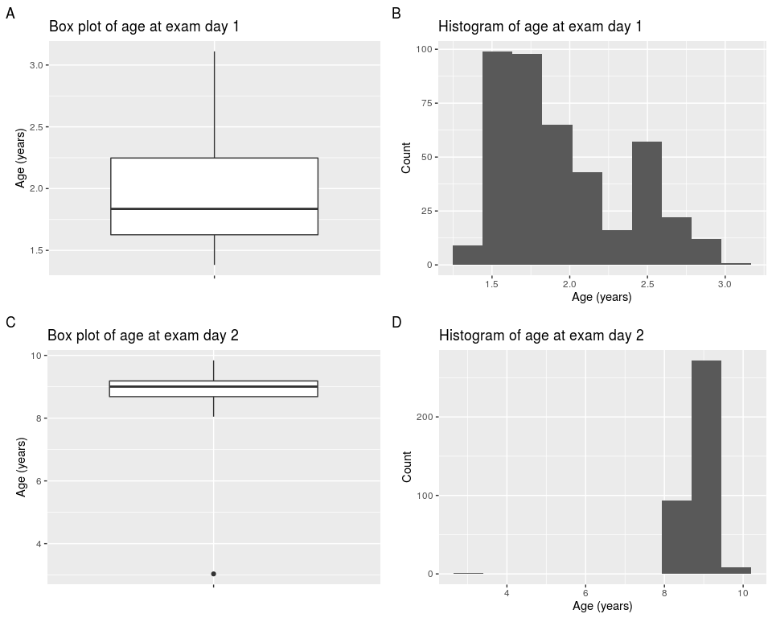

```r
p1 = ggplot(data, aes(x='', age1)) +
  geom_boxplot(na.rm=TRUE) +
  labs(tag='A', x='', y='Age (years)', title='Box plot of age at exam day 1')
p2 = ggplot(data, aes(age1)) +
  geom_histogram(na.rm=TRUE, bins=10) +
  labs(tag='B', title='Histogram of age at exam day 1', x='Age (years)', y='Count')
p3 = ggplot(data, aes(x='', age2)) +
  geom_boxplot(na.rm=TRUE) +
  labs(tag='C', x='', y='Age (years)', title='Box plot of age at exam day 2')
p4 = ggplot(data, aes(age2)) +
  geom_histogram(na.rm=TRUE, bins=10) +
  labs(tag='D', title='Histogram of age at exam day 2', x='Age (years)', y='Count')
multiplot(p1, p3, p2, p4, cols=2)
```

Similarly, we plot the distribution of the weight and the height variables below. We see an outlier with the birth height of about 1 meter, which we will remove. Although we see some other outliers we don’t have any rationale for removing them.

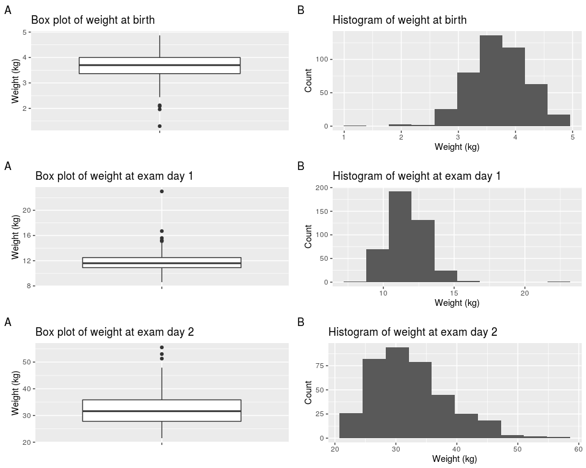

```r
p1 = ggplot(data, aes(x='', w0)) +
  geom_boxplot(na.rm=TRUE) +
  labs(tag='A', x='', y='Weight (kg)', title='Box plot of weight at birth')
p2 = ggplot(data, aes(w0)) +
  geom_histogram(na.rm=TRUE, bins=10) +
  labs(tag='B', x='Weight (kg)', y='Count', title='Histogram of weight at birth')
p3 = ggplot(data, aes(x='', w1)) +
  geom_boxplot(na.rm=TRUE) +
  labs(tag='A', x='', y='Weight (kg)', title='Box plot of weight at exam day 1')
p4 = ggplot(data, aes(w1)) +
  geom_histogram(na.rm=TRUE, bins=10) +
  labs(tag='B', x='Weight (kg)', y='Count', title='Histogram of weight at exam day 1')
p5 = ggplot(data, aes(x='', w2)) +
  geom_boxplot(na.rm=TRUE) +
  labs(tag='A', x='', y='Weight (kg)', title='Box plot of weight at exam day 2')
p6 = ggplot(data, aes(w2)) +
  geom_histogram(na.rm=TRUE, bins=10) +
  labs(tag='B', x='Weight (kg)', y='Count', title='Histogram of weight at exam day 2')
multiplot(p1, p3, p5, p2, p4, p6, cols=2)
```

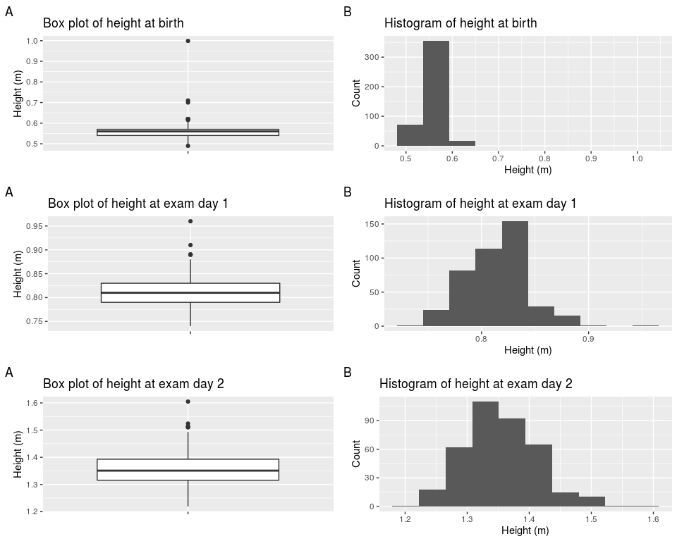

```r
p1 = ggplot(data, aes(x='', h0)) +
  geom_boxplot(na.rm=TRUE) +
  labs(tag='A', x='', y='Height (m)', title='Box plot of height at birth')
p2 = ggplot(data, aes(h0)) +
  geom_histogram(na.rm=TRUE, bins=10) +
  labs(tag='B', x='Height (m)', y='Count', title='Histogram of height at birth')
p3 = ggplot(data, aes(x='', h1)) +
  geom_boxplot(na.rm=TRUE) +
  labs(tag='A', x='', y='Height (m)', title='Box plot of height at exam day 1')
p4 = ggplot(data, aes(h1)) +
  geom_histogram(na.rm=TRUE, bins=10) +
  labs(tag='B', x='Height (m)', y='Count', title='Histogram of height at exam day 1')
p5 = ggplot(data, aes(x='', h2)) +
  geom_boxplot(na.rm=TRUE) +
  labs(tag='A', x='', y='Height (m)', title='Box plot of height at exam day 2')
p6 = ggplot(data, aes(h2)) +
  geom_histogram(na.rm=TRUE, bins=10) +
  labs(tag='B', x='Height (m)', y='Count', title='Histogram of height at exam day 2')
multiplot(p1, p3, p5, p2, p4, p6, cols=2)
```

As we see below, when we filter the data we only remove two outliers, based on criteria discussed above.

```r
# Number of observation before filter.
n_before = dim(data)[1]
# Remove outliers.
data = data %>% filter(age2 > 4 | is.na(age2)) %>%
  filter(h0 < 0.9 | is.na(h0))
# Number of observations after filter.
n_after = dim(data)[1]
# Print difference.
print(n_before - n_after)
```

```
[1] 2
```

# Impute missing data

Before we impute missing data, let’s find out how many values are missing in each observation. Below, we see that most are missing none, many are missing three, and only a few are missing 6 values.

```r
# Count the number of NA values in each observation and calculate a table.
is.na(data) %>% rowSums() %>% table()
```

```
.
  0   1   3   6
353   2  84   5
```

Let’s also do this for each variable. Not surprisingly, exam day 2 has the most missing values.

```r
# Count number of NA values in each variable.
is.na(data) %>% colSums()
```

```
gender     w0     h0     h1     w1     h2     w2   age1   age2
     0      0      1     24     25     70     70     24     70
```

We use the `missForest()` function to impute missing data. There are many packages that perform imputation, but we chose this one because it makes few assumptions about the data. We could probably have used the MICE R package, which among other things assumes that the data follows a multivariate normal distribution.

Note that we pass the `verbose=TRUE` argument to `missForest()`, which makes `missForest()` give us more information for each iteration (round) of imputation. Note by the error and the difference that the error drops quite quickly, such that we probably only needed a single iteration.

```r
# Convert the tibble to dataframe befoew running imputation.
imp <- data %>%
  as.data.frame() %>%
  missForest(verbose=TRUE)
```

```
  missForest iteration 1 in progress...done!
    estimated error(s): 0.1542297 0
    difference(s): 0.001429285 0
    time: 1.851 seconds

  missForest iteration 2 in progress...done!
    estimated error(s): 0.1552789 0
    difference(s): 0.0001688379 0
    time: 1.362 seconds

  missForest iteration 3 in progress...done!
    estimated error(s): 0.1524495 0
    difference(s): 0.0001482733 0
    time: 1.327 seconds

  missForest iteration 4 in progress...done!
    estimated error(s): 0.1549887 0
    difference(s): 5.877677e-05 0
    time: 1.408 seconds

  missForest iteration 5 in progress...done!
    estimated error(s): 0.1524853 0
    difference(s): 3.942262e-05 0
    time: 1.491 seconds

  missForest iteration 6 in progress...done!
    estimated error(s): 0.1543504 0
    difference(s): 7.13651e-05 0
    time: 1.504 seconds
```

```r
imp$OOBerror
```

```
    NRMSE       PFC
0.1524853 0.0000000
```

We extract the data from the `missForest()` object, `imp`, which is a matrix, and convert it to a tibble.

```r
# Get the imputed data and convert it to a tibble.
data_imp <- imp$ximp %>% as_tibble()
```

# Calculate BMI

Now that we have cleaned up our data by removing outliers and imputing missing values, let’s calculate the BMI of each individual at three time points, birth and exam day 1 and 2.

```r
# Compute BMI at birth and at exam days 1 and 2, and add columns to data.
data_imp = data_imp %>% mutate(bmi0=w0/h0^2,
                       bmi1=w1/h1^2,
                       bmi2=w2/h2^2)
```

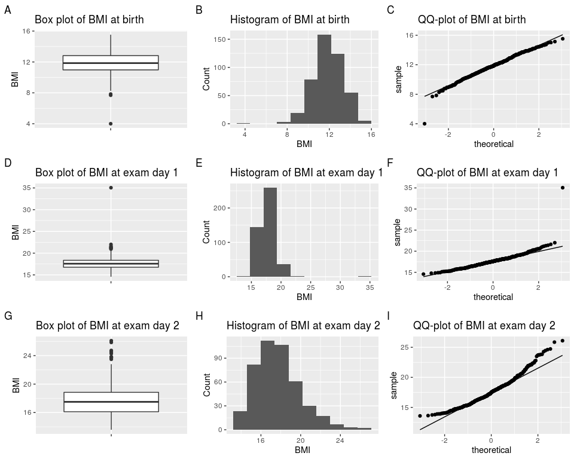

```r
p1 = ggplot(data_imp, aes(x='', bmi0)) +
  geom_boxplot(na.rm=TRUE) +
  labs(tag='A', x='', y='BMI', title='Box plot of BMI at birth')
p2 = ggplot(data_imp, aes(bmi0)) +
  geom_histogram(na.rm=TRUE, bins=10) +
  labs(tag='B', title='Histogram of BMI at birth', x='BMI', y='Count')
p3 = ggplot(data_imp, aes(sample=bmi0)) +
  stat_qq(na.rm=TRUE) + stat_qq_line(na.rm=TRUE) +
  labs(tag='C', title='QQ-plot of BMI at birth')
p4 = ggplot(data_imp, aes(x='', bmi1)) +
  geom_boxplot(na.rm=TRUE) +
  labs(tag='D', x='', y='BMI', title='Box plot of BMI at exam day 1')
p5 = ggplot(data_imp, aes(bmi1)) +
  geom_histogram(na.rm=TRUE, bins=10) +
  labs(tag='E', title='Histogram of BMI at exam day 1', x='BMI', y='Count')
p6 = ggplot(data_imp, aes(sample=bmi1)) +
  stat_qq(na.rm=TRUE) + stat_qq_line(na.rm=TRUE) +
  labs(tag='F', title='QQ-plot of BMI at exam day 1')
p7 = ggplot(data_imp, aes(x='', bmi2)) +
  geom_boxplot(na.rm=TRUE) +
  labs(tag='G', x='', y='BMI', title='Box plot of BMI at exam day 2')
p8 = ggplot(data_imp, aes(bmi2)) +
  geom_histogram(na.rm=TRUE, bins=10) +
  labs(tag='H', title='Histogram of BMI at exam day 2', x='BMI', y='Count')
p9 = ggplot(data_imp, aes(sample=bmi2)) +
  stat_qq(na.rm=TRUE) + stat_qq_line(na.rm=TRUE) +
  labs(tag='I', title='QQ-plot of BMI at exam day 2')
multiplot(p1, p4, p7, p2, p5, p8, p3, p6, p9, cols=3)
```

# Save data

Say we want to share this data with colleagues, then we need to save it somehow. We can do this with the `write_csv()` function, supplying the tibble and a path where want to write the data. This writes the data in a standard CSV file with comma delimitation. Storing the cleaned-up data we also avoid having to deal with the messy nature of the original data, so that we can import it directly with `read_csv('weight_height_cleanup.csv')` and start analysing.

```r
write_csv(data_imp, 'weight_height_cleanup.csv')
```